# PSTAT 10: Homework 5

Ward, Sofia: sofiaward

Due on Canvas by 11:59pm on Week 5 Wednesday November 2

# Instructions for Submission

- This homework is a bit of a review homework, in that it contains problems on several topics covered in the course thus far. **PLEASE NOTE: this is by no means meant to be comprehensive.**
- This homework consists of two parts: Computing Exercises, and Theory Exercises.
- The submission portal on Canvas has 3 questions:
  - One for uploading your `.html` file for the Computing Exercises
  - One for uploading your `.zip` file containing both the `.html` and `.Rmd` files (along with any relevant datasets/images) for the Computing Exercises
  - One for uploading a `.PDF` of a photo or scan of your handwritten work for the Theory Exercises
- No multiple choice questions for this homework, but please review the previous multiple choice questions from the past few weeks.
- Remember to save your `.Rmd` file as `hw05-yournetid.Rmd`

# Computing Exercises:

## Exercise 1: Listlessness

**(a)** Construct a list called `my_list` that contains 4 members:

- The first member should be a vector of integers from 3 to 20, inclusive
- The second member should be a vector containing the words `cat`, `dog`, `elephant`, `giraffe`, and `hippopotamus`
- The third member should be a $4 \times 2$ matrix containing the even numbers from 2 to 16, inclusive, where the elements are fed in by row.
- The fourth member should be the vector `A+, A, A-, B+, B, B-, C+, C, C-` encoded as an ordered factor.

**Solutions**

```r
n <- ordered(c("A+", 'A', 'A-', 'B+', 'B', 'B-', 'C+', 'C', 'C-'))
maty <- seq(from = 2, to = 16, by = 2)
my_list <- list(c(3:20), c("cat", "dog", "elephant", "giraffe", "hippopotamus"), matrix(maty, nrow = 4, ncol = 2), ordered(n))
my_list
```

```
## [[1]]
##  [1]  3  4  5  6  7  8  9 10 11 12 13 14 15 16 17 18 19 20
##
## [[2]]
## [1] "cat"          "dog"          "elephant"     "giraffe"      "hippopotamus"
##
## [[3]]
##      [,1] [,2]
## [1,]    2   10
## [2,]    4   12
## [3,]    6   14
## [4,]    8   16
##
## [[4]]
## [1] A+ A  A- B+ B  B- C+ C  C-
## Levels: A < A- < A+ < B < B- < B+ < C < C- < C+
```

**(b)** Access the first member of `my_list`, and check that it has really been stored as an integer Data Type.

**Solutions**

```r
m <- my_list[[1]]
m
```

```
##  [1]  3  4  5  6  7  8  9 10 11 12 13 14 15 16 17 18 19 20
```

```r
typeof(m)
```

```
## [1] "integer"
```

**(c)** Access the fourth member of `my_list`, and check that it has really been stored as an ordered factor Data Structure.

**Solutions**

```r
meow <- my_list[[4]]
is.ordered(meow)
```

```
## [1] TRUE
```

**(d)** Write code to access the second member of `my_list`, displayed in descending alphabetical order.

**Solutions**

```r
listy <- my_list[[2]]
sort(listy, decreasing = T)
```

```
## [1] "hippopotamus" "giraffe"      "elephant"     "dog"          "cat"
```

**(e)** Write code that subsets the members and/or elements of members of `my_list` to return the output `2`.

**Solutions**

```r
mate <- my_list[[3]]
ncol(mate)
```

```
## [1] 2
```

**(f)** Write code to assign the names `member1`, `member2`, `member3`, and `member4` to the members of the list. Then, extract the names of `my_list` using a function and ensure everything was assigned properly. As a reminder, be sure to print `my_list` at the end

**Solutions**

```r
names(my_list) <- c("member1", "member2", "member3", "member4")
my_list
```

```
## $member1
##  [1]  3  4  5  6  7  8  9 10 11 12 13 14 15 16 17 18 19 20
##
## $member2
## [1] "cat"          "dog"          "elephant"     "giraffe"      "hippopotamus"
##
## $member3
##      [,1] [,2]
## [1,]    2   10
## [2,]    4   12
## [3,]    6   14
## [4,]    8   16
##
## $member4
## [1] A+ A  A- B+ B  B- C+ C  C-
## Levels: A < A- < A+ < B < B- < B+ < C < C- < C+
```

## Exercise 2: String Lights

Consider the string `"String Lights Make My Apartment Look Real Sophisticated."`

**(a)** Write code to access the word `"Lights"`. **Hint:** One of the functions we dealt with on a previous homework may help here.

**Solutions**

```r
word <- "String Lights Make My Apartment Look Real Sophisticated."
new <- strsplit(word, " ")
x <- new[[1]]
x[2]
```

```
## [1] "Lights"
```

```r
#that took forever
```

**Solutions**

**(b)** Replace all instances of the letter `t` with `z`.

```r
gsub('t', 'z', word)
```

```
## [1] "Szring Lighzs Make My Aparzmenz Look Real Sophiszicazed."
```

## Exercise 3: Sleep Study

A recent study at surveyed several undergraduate students on their sleep habits. The results are stored in the dataset `sleep.csv`, which contains the following variables:

- `age`: the age of each individual
- `standing`: the standing (`Freshman`, `Sophomore`, `Junior`, `Senior`, `SuperSenior`) of each individual
- `sleep`: the amount of sleep (in hours) each individual had on average, per night
- `gender`: the gender of each student (`female`, `male`, `nonbinary`)
- `coffee`: the average number of cups of coffee each individual drinks, per day

**(a)** Read in the data.

**Solutions**

```r
sleep <- read.csv("~/sofiaward_workingfiles/hw/homework 5/data/sleep.csv")
```

**(b)** Are there any missing values? If so, which variable(s) contain missing values?

**Solutions**

```r
which(is.na(sleep$coffee))
```

```
## [1]  64 102 113
```

coffee contains missing values at index 64, 102, and 113

**(c)** Generate an appropriate plot to visualize the distribution of ages represented in this study.

**Solutions**

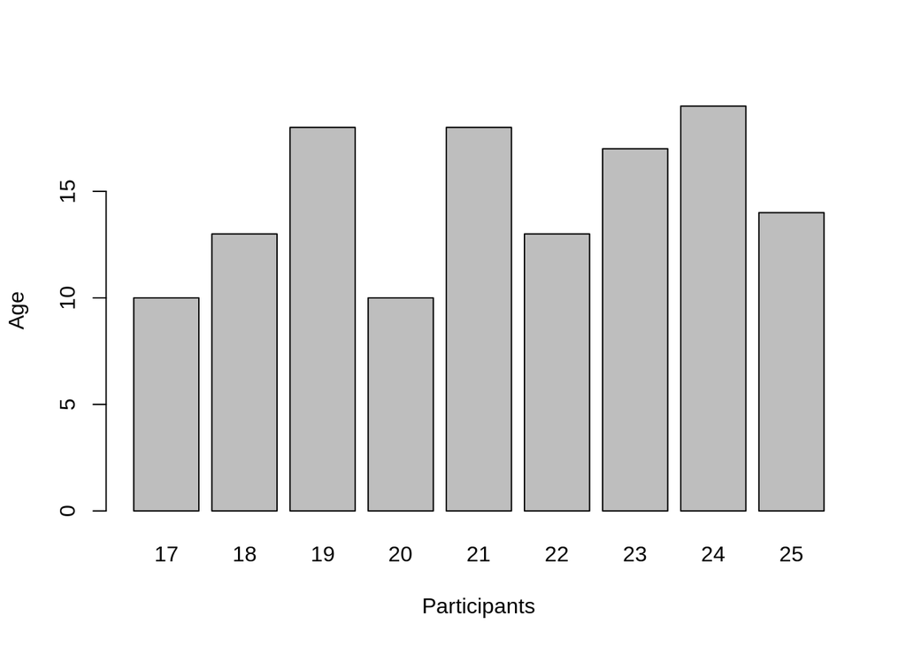

```r
barplot(table(sleep$age), xlab = "Participants", ylab = "Age")
```

**(d)** Generate an appropriate plot to visualize the distribution of average daily coffee consumption. (Hint: note that the variable `coffee` contains only integer values.)

**Solutions**

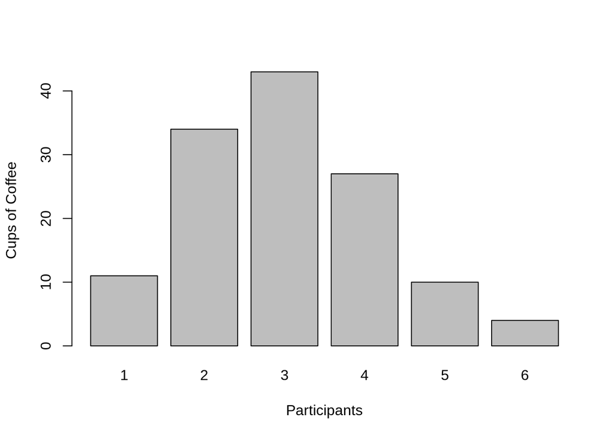

```r
barplot(table(sleep$coffee), xlab = "Participants", ylab = "Cups of Coffee")
```

**(e)** Generate an appropriate plot to visualize the distribution of genders present in this study.

**Solutions**

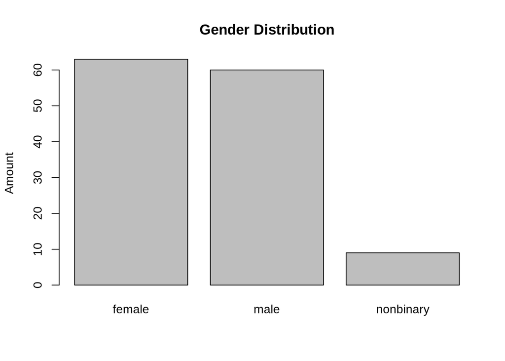

```r
sleep <- read.csv("~/sofiaward_workingfiles/hw/homework 5/data/sleep.csv")
barplot(table(sleep$gender), main = "Gender Distribution", ylab = "Amount")
```

**(f)** Generate a plot to visualize the relationship between `sleep` and `standing`. Does any particular standing appear to get less sleep (on average) than other standings?

**Solutions**

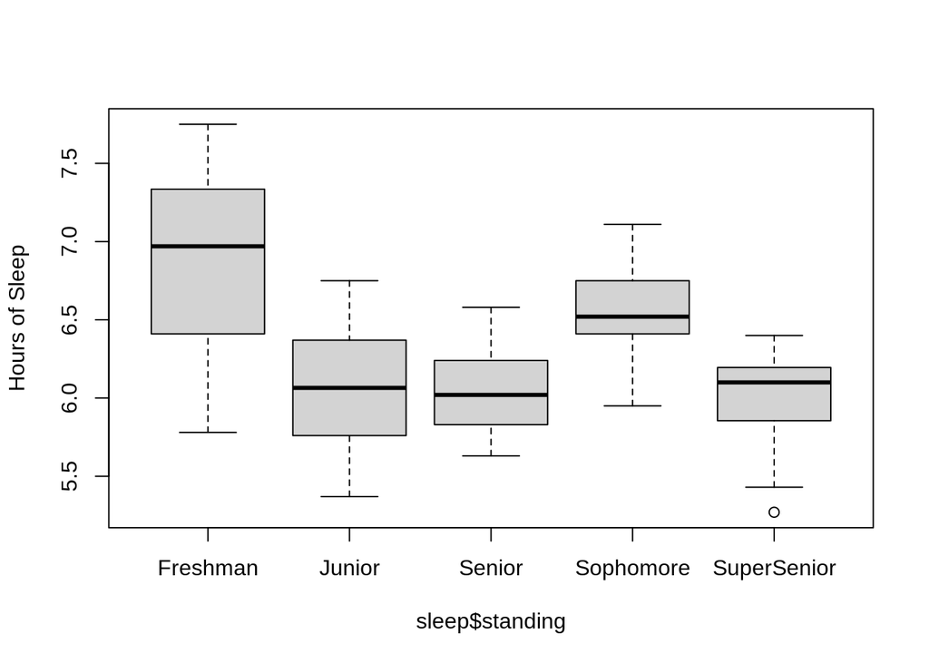

```r
slep <- any(is.na(sleep$sleep))
stand <- any(is.na(sleep$standing))

boxplot(sleep$sleep ~ sleep$standing, ylab = "Hours of Sleep")
```

**(g)** Plot the relationship between `sleep` (on the y-axis) and `age` (on the x-axis).

**Solutions**

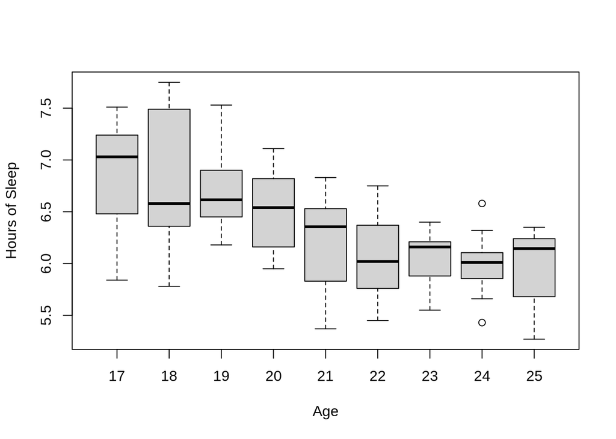

```r
boxplot(sleep$sleep ~ sleep$age, xlab = "Age", ylab = "Hours of Sleep")
```

**(h)** Provide a numerical summary of the average amount of sleep of participants in the study.

**Solutions**

```r
summary(sleep$sleep)
```

```
##    Min. 1st Qu.  Median    Mean 3rd Qu.    Max.
##   5.270   5.933   6.280   6.313   6.580   7.750
```

**(i)** Test the normality of the values in the `sleep` variable.

**Solutions** The values are kinda 50% on the red line and not on the line

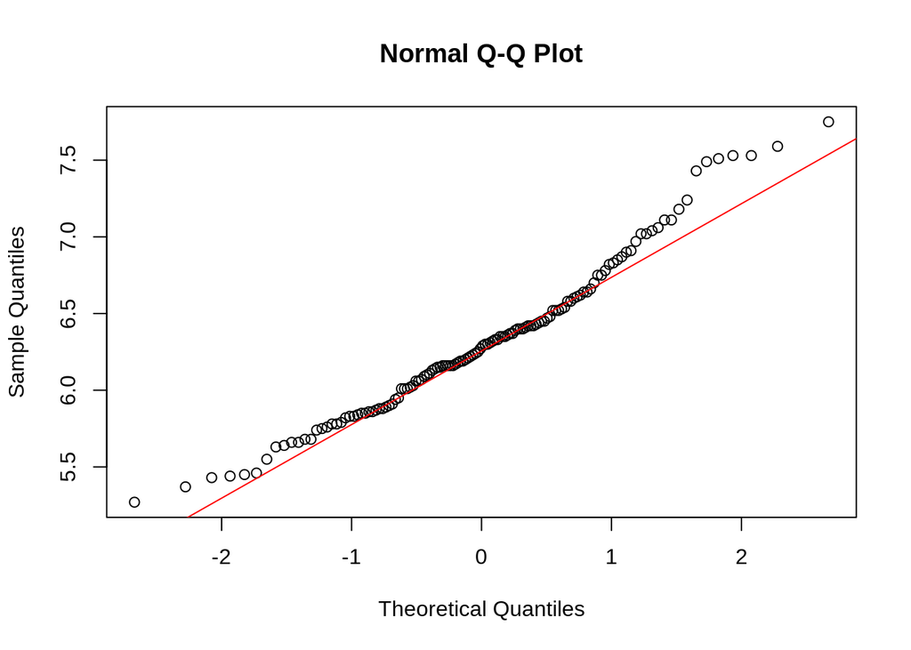

```r
qqnorm(sleep$sleep)
qqline(sleep$sleep, col = "red")
```

## Exercise 4: Phone a Friend

The amount of time a randomly selected person spends on the phone in a given day is normally distributed with mean 8hrs and a standard deviation 1.5hrs.

**(a)** What is the probability that a randomly selected person will spend between 8 and 10 hours on their phone in a given day?

**Solutions**

```r
pnorm(10, 8, 1.5) - pnorm(8, 8, 1.5)
```

```
## [1] 0.4087888
```

**(b)** Now, a sample of 123 people is taken with replacement. What is the probability that exactly 36 of them spend between 8 and 10 hours on their phone in a given day? **Hint:** You’ll need to use your answer from part (a).

**Solutions**

```r
dbinom(36, 123,0.4087888)
```

```
## [1] 0.002216475
```

## Exercise 5: Betting Odds

A magical genie approaches you one day, and makes you an offer to give you $100 if you win a game. He offers you the choice to play one of the following two games:

- **Game A:** The genie tosses 100 fair coins; you win if more than 50 of the tosses land on heads.
- **Game B:** The genie tosses 1000 fair coins; you win if more than 500 of the tosses land on heads.

Which game should you play? In other words, in which of the two games are your chances of winning the $100 higher? Be sure to justify your answer.

**Solutions**

```r
gamea <- sample(c("H", "T") , 100, replace = TRUE )
table(gamea)
```

```
## gamea
##  H  T
## 59 41
```

```r
gameb <- sample(c("H", "T") , 1000, replace = TRUE )
table(gameb)
```

```
## gameb
##   H   T
## 497 503
```

Either game would be the same odds, but I would pick the game with 100 tosses just because there is more room for error with less tosses

## Exercise 6: Re-Inventing the Wheel

In this problem, we are going to define our own function to compute factorials.

**(a)** Fill in the blanks in the following code so that it correctly computes $8!$ using a `while` loop.

```r
n <- 8

counter <- 1
prod <- 1

while(counter <= ______){
  prod <- prod * ______
  counter <- ______ + ______
}

print(______)
```

**Solutions:**

```r
n <- 8

counter <- 1
prod <- 1

while(counter <= n){
  prod <- prod * counter
  counter <- counter + 1
}

print(prod)
```

```
## [1] 40320
```

**(b)** Now, look up the `stop()` function in `R`. Describe what it does.

**Solutions:**

stop stops execution of the current expression and executes an error action.

‘geterrmessage’ gives the last error message.

**(c)** Finally, make a function `newfactorial()` that takes in a single input `n` and returns $n!$. Some things to keep in mind:

- In the body of your function, you will need to use the `while` loop you constructed in part (a).
- Your function should be able to compute $0!$ as 1.
- If you try calling `newfactorial()` on a number that is either negative or not an integer, `newfactorial()` should output an error stating “Error: input must be a natural number or 0.” **Hint:** Think about how you can use the modulo operator `%%` to determine whether a given number is an integer or not.

As always, you should test your function with a few different inputs. Specifically, test that

- `newfactorial(8)` matches with the output of `factorial(8)`
- `newfactorial(0)` correctly outputs `1`
- `newfactorial(-1)` correctly outputs an error (remember you may need to fiddle around with your code chunk options to get things to knit properly!)

**Solutions:**

```r
newfactorial <- function(n){
  if (is.double(n) == FALSE){
    print("Error: input must be a natural number or 0.")
  }
  if (n %% 2 != 0){
    print("Error: input must be a natural number or 0.")
  }
  if (n == 0){
    return(1)
  } else
  if (n < 0){
    print("Error: input must be a natural number or 0.")
  } else {
    counter <- 1
    prod <- 1

    while(counter <= n){
      prod <- prod * counter
      counter <- counter + 1
      }

    print(prod)
}}
newfactorial(8)
```

```
## [1] 40320
```

```r
newfactorial(0)
```

```
## [1] 1
```

```r
newfactorial(-1)
```

```
## [1] "Error: input must be a natural number or 0."
## [1] "Error: input must be a natural number or 0."
```

# Theory Exercises

## Exercise 7: Life Was Like a Box of Chocolates

In a box there are 24 pieces of candy. 18 of these candies have a milk chocolate coating, and 6 have a white chocolate coating. Two thirds of the milk chocolate candies have a Marzipan filling. In total, there are 16 candies with Marzipan filling.

1. Find the probability of randomly selecting a candy that is either coated in white chocolate or filled with Marzipan.
2. Suppose you randomly selected a candy, opened it, and noted that is has a white chocolate coating. What is the probability that it has a marzipan filling?

## Exercise 8: Counting Cards

Two cards are drawn at random and without replacement from a standard deck of cards.

1. What is the probability that the second card is an ace, given that the first card was an ace?
2. What is the probability that both cards are aces?